# Table of Contents

## Chapter Outline

1. Introduction
2. Import algorithm backtest data
3. Evaluate algorithm results
4. Conclusions
5. Resource and Citations

## Introduction

After learning that the Gaussian Mixture Model and the historical VAR models were relatively effective in forecasting VAR I decided to test an inverse VAR portfolio allocation algorithm verse some common benchmarks.

The symbol universe consisted of the following ETFs:

*"SPY", "QQQ", "DIA", "TLT", "GLD", "EFA", "EEM", 'BND', 'VNQ'*

- All the algorithms start from `2007-12-31` and run until `2019-05-08`.
- Rebalance monthly
- Target weights had a 5% corridor or +/- 2.5% (to minimize transaction costs).

The benchmark algorithms are the equal weight and 60/40 SPY/BND algorithm.

I tested 2 Historical VAR models. One with a lookback of 252 days and the other with a lookback 60 days.

I tested 2 GMM VAR models. One with a lookback of 252 days and the other, 60 days. I restricted the model to 2 components.

## Read in the data

```python
filenames = [
    "equal_weight_benchmark_[2019-05]",
    "60_40_benchmark_[2019-05]",
    "gmm2_60_[2019-05]",
    "gmm2_252_[2019-05]",
    "historical_60_[2019-05]",
    "historical_252_[2019-05]",
]

dfs = [read_port_equity(Path(project_dir / "data"), f"{fn}.json") for fn in filenames]
df = pd.concat(dfs, axis=1).sort_index().dropna().drop_duplicates()
cprint(df)
```

```
-------------------------------------------------------------------------------
dataframe information
-------------------------------------------------------------------------------
                           equal_weight_benchmark_[2019-05]  \
time
2019-05-02 20:00:00+00:00                      208,709.9848
2019-05-03 17:03:00+00:00                      210,300.5198
2019-05-03 20:00:00+00:00                      210,445.3648
2019-05-06 13:31:00+00:00                      207,961.7448
2019-05-06 20:00:00+00:00                      209,486.4098

                           60_40_benchmark_[2019-05]  gmm2_60_[2019-05]  \
time
2019-05-02 20:00:00+00:00               211,104.8538       195,237.2408
2019-05-03 17:03:00+00:00               212,385.3838       196,455.0358
2019-05-03 20:00:00+00:00               212,444.9538       196,570.1258
2019-05-06 13:31:00+00:00               210,535.0938       194,868.9658
2019-05-06 20:00:00+00:00               212,039.7038       196,012.7658

                           gmm2_252_[2019-05]  historical_60_[2019-05]  \
time
2019-05-02 20:00:00+00:00        189,301.2864             193,244.1758
2019-05-03 17:03:00+00:00        190,323.5714             194,423.5208
2019-05-03 20:00:00+00:00        190,407.9914             194,545.2758
2019-05-06 13:31:00+00:00        189,218.7314             192,881.1358
2019-05-06 20:00:00+00:00        190,006.5414             193,982.6208

                           historical_252_[2019-05]
time
2019-05-02 20:00:00+00:00              190,181.8060
2019-05-03 17:03:00+00:00              191,124.6860
2019-05-03 20:00:00+00:00              191,210.0360
2019-05-06 13:31:00+00:00              190,217.4960
2019-05-06 20:00:00+00:00              190,876.3260
--------------------------------------------------
<class 'pandas.core.frame.DataFrame'>
DatetimeIndex: 5566 entries, 2007-12-31 05:00:00+00:00 to 2019-05-06 20:00:00+00:00
Data columns (total 6 columns):
equal_weight_benchmark_[2019-05]    5566 non-null float64
60_40_benchmark_[2019-05]           5566 non-null float64
gmm2_60_[2019-05]                   5566 non-null float64
gmm2_252_[2019-05]                  5566 non-null float64
historical_60_[2019-05]             5566 non-null float64
historical_252_[2019-05]            5566 non-null float64
dtypes: float64(6)
memory usage: 304.4 KB
None
-------------------------------------------------------------------------------
```

## Calculate Performance

```python
# strategy returns

for col in df.columns:
    strats[col] = np.log(df[col] / df[col].shift(1))
cprint(strats)
```

```
-------------------------------------------------------------------------------
dataframe information
-------------------------------------------------------------------------------
                           equal_weight_benchmark_[2019-05]  \
time
2019-05-02 20:00:00+00:00                            0.0018
2019-05-03 17:03:00+00:00                            0.0076
2019-05-03 20:00:00+00:00                            0.0007
2019-05-06 13:31:00+00:00                           -0.0119
2019-05-06 20:00:00+00:00                            0.0073

                           60_40_benchmark_[2019-05]  gmm2_60_[2019-05]  \
time
2019-05-02 20:00:00+00:00                     0.0024             0.0016
2019-05-03 17:03:00+00:00                     0.0060             0.0062
2019-05-03 20:00:00+00:00                     0.0003             0.0006
2019-05-06 13:31:00+00:00                    -0.0090            -0.0087
2019-05-06 20:00:00+00:00                     0.0071             0.0059

                           gmm2_252_[2019-05]  historical_60_[2019-05]  \
time
2019-05-02 20:00:00+00:00              0.0012                   0.0016
2019-05-03 17:03:00+00:00              0.0054                   0.0061
2019-05-03 20:00:00+00:00              0.0004                   0.0006
2019-05-06 13:31:00+00:00             -0.0063                  -0.0086
2019-05-06 20:00:00+00:00              0.0042                   0.0057

                           historical_252_[2019-05]
time
2019-05-02 20:00:00+00:00                    0.0011
2019-05-03 17:03:00+00:00                    0.0049
2019-05-03 20:00:00+00:00                    0.0004
2019-05-06 13:31:00+00:00                   -0.0052
2019-05-06 20:00:00+00:00                    0.0035
--------------------------------------------------
<class 'pandas.core.frame.DataFrame'>
DatetimeIndex: 5566 entries, 2007-12-31 05:00:00+00:00 to 2019-05-06 20:00:00+00:00
Data columns (total 6 columns):
equal_weight_benchmark_[2019-05]    5565 non-null float64
60_40_benchmark_[2019-05]           5565 non-null float64
gmm2_60_[2019-05]                   5565 non-null float64
gmm2_252_[2019-05]                  5565 non-null float64
historical_60_[2019-05]             5565 non-null float64
historical_252_[2019-05]            5565 non-null float64
dtypes: float64(6)
memory usage: 304.4 KB
None
-------------------------------------------------------------------------------
```

## Evaluate Performance

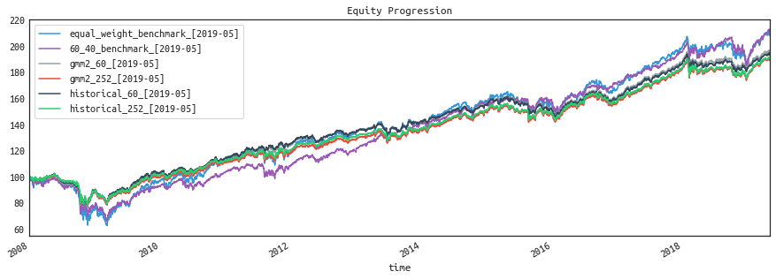

```python
perf = ffn.calc_stats(df)
perf.plot()
```

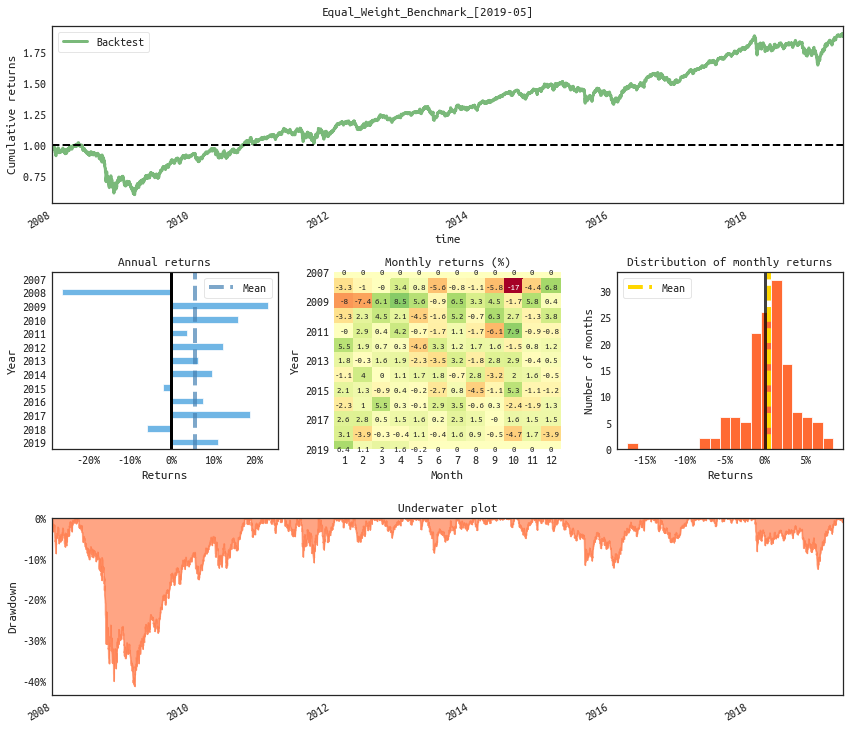

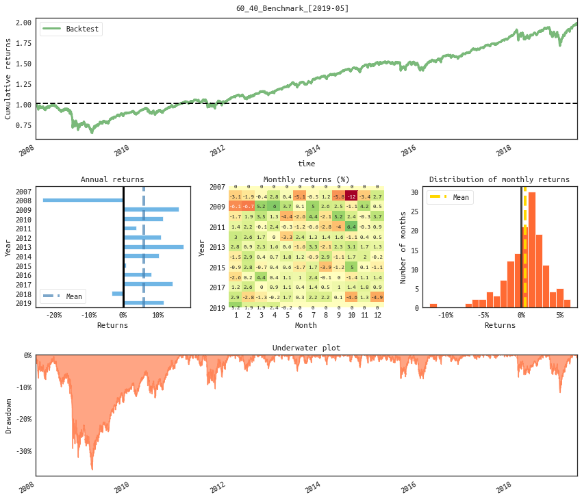

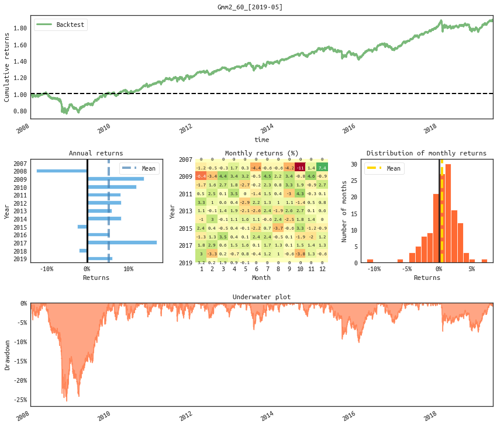

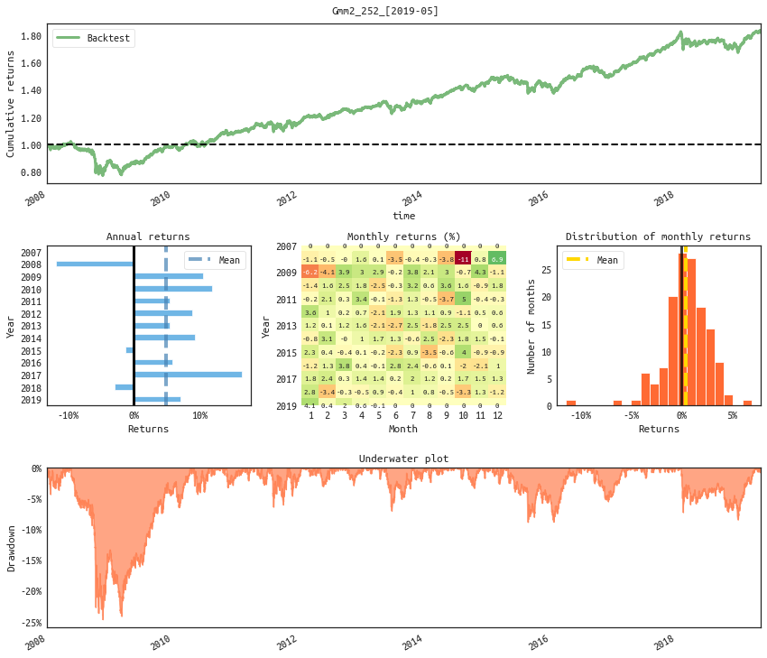

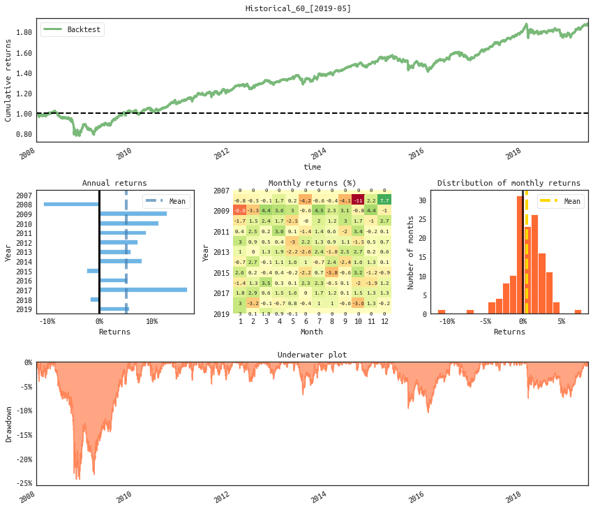

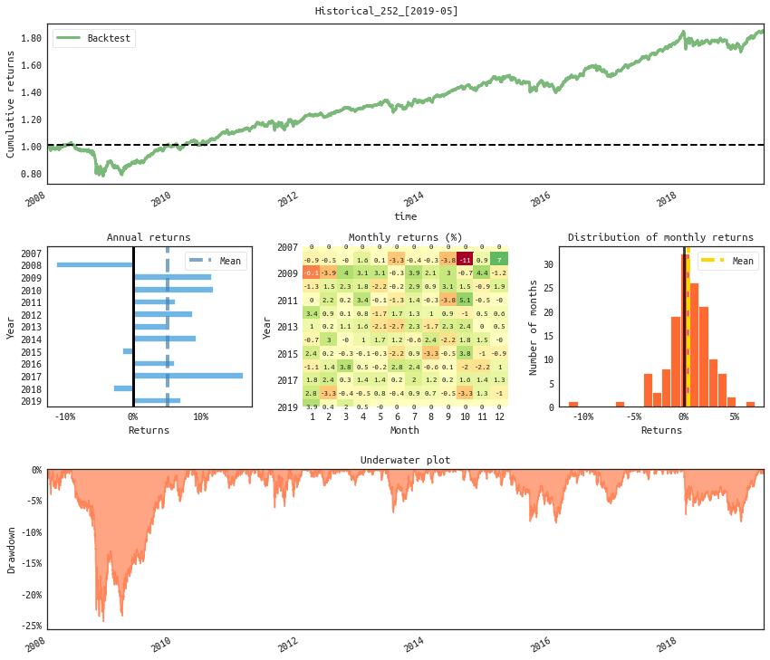

```python
for col in strats.columns:
    plot_pf(strats[col])
    plt.suptitle(col.title(), y=1.01)
```

[figure not shown]

```python
ax = (
    strat_res.loc["common_sense_ratio"]
    .sort_values()
    .plot.barh(title="Common Sense Ratios")
)

plt.axvline(1.0, color="r")
add_watermark(ax, scale=1.25)
```

[figure not shown]

```python
ax = strat_res.loc["calmar"].sort_values().plot.barh(title="Calmar Ratios")
plt.xlim(0)
plt.axvline(strat_res.loc["calmar"].mean(), color="r")
add_watermark(ax, scale=1.25)
```

[figure not shown]

```python
ax = (
    strat_res.loc["yearly_sharpe"].sort_values().plot.barh(title="Yearly Sharpe Ratios")
)
plt.axvline(strat_res.loc["yearly_sharpe"].mean(), color="r")
add_watermark(ax, scale=1.25)
```

[figure not shown]

```python
ax = (
    strat_res.loc["avg_worst_5_drawdowns"]
    .sort_values(ascending=True)
    .plot.barh(title="Avg of 5 Worst Drawdowns")
)
ax.axvline(strat_res.loc["avg_worst_5_drawdowns"].mean(), color="r")
add_watermark(ax, scale=1.25)
```

[figure not shown]

```python
ax = (
    strat_res.loc["max_drawdown"].sort_values().plot.barh(title="Strategy Max Drawdown")
)
ax.axvline(strat_res.loc["max_drawdown"].mean(), color="r")
add_watermark(ax, scale=1.25)
```

[figure not shown]

```python
plot_avg_drawdown_grid()
```

[figure not shown]

```python
_ = plot_csr_by_maxdd()
```

[figure not shown]

```python
_ = plot_maxdd_by_sharpe()
```

```python
perf["gmm2_252_[2019-05]"].display_monthly_returns()
```

```
  Year    Jan    Feb    Mar    Apr    May    Jun    Jul    Aug    Sep     Oct    Nov    Dec     YTD
------  -----  -----  -----  -----  -----  -----  -----  -----  -----  ------  -----  -----  ------
  2007   0      0      0      0      0      0      0      0      0       0      0      0       0
  2008  -1.07  -0.49   0.01   1.66   0.12  -3.45  -0.4   -0.25  -3.68  -10.92   1.04   7.14  -10.73
  2009  -6.08  -4.09   4.02   3.1    2.94  -0.22   3.87   2.17   3.02   -0.68   4.34  -1.1    11.17
  2010  -1.37   1.59   2.52   1.79  -2.45  -0.29   3.18   0.58   3.64    1.67  -0.86   1.85   12.29
  2011  -0.15   2.15   0.3    3.39  -0.08  -1.33   1.3   -0.42  -3.6     5.04  -0.34  -0.27    5.88
  2012   3.57   0.99   0.21   0.72  -2.06   1.95   1.32   1.12   0.94   -1.13   0.54   0.61    9.03
  2013   1.2    0.12   1.25   1.61  -2.08  -2.7    2.47  -1.8    2.51    2.55   0.03   0.58    5.71
  2014  -0.76   3.13   0.01   1.06   1.72   1.27  -0.58   2.48  -2.32    1.81   1.51  -0.1     9.49
  2015   2.36   0.38  -0.37   0.08  -0.21  -2.25   0.95  -3.42  -0.57    4.02  -0.92  -0.86   -1.02
  2016  -1.14   1.29   3.82   0.46  -0.09   2.83   2.43  -0.62   0.15   -1.99  -2.08   1.03    6.06
  2017   1.79   2.42   0.32   1.38   1.4    0.2    1.96   1.22   0.21    1.71   1.52   1.31   16.55
  2018   2.76  -3.28  -0.28  -0.52   0.93  -0.36   1.04   0.77  -0.52   -3.29   1.34  -1.15   -2.68
  2019   4.09   0.41   2      0.62  -0.08   0      0      0      0       0      0      0       7.18
```

```
findfont: Font family ['Arial'] not found. Falling back to DejaVu Sans.
findfont: Font family ['Arial'] not found. Falling back to DejaVu Sans.
```

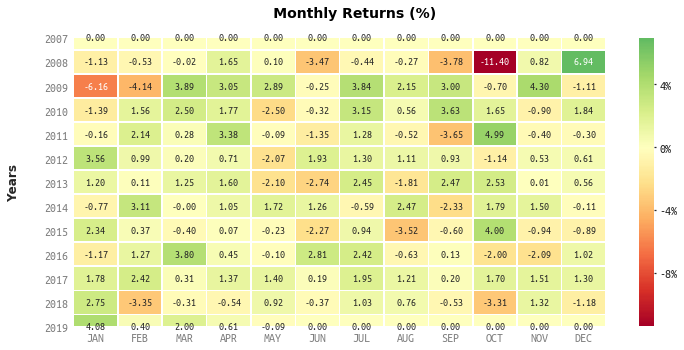

```python
plt.figure(figsize=(12, 10))
qs.plots.monthly_heatmap(strats["gmm2_252_[2019-05]"])
```

## Conclusions

The `gmm2_252` algorithm is the updated winner on a risk-adjusted basis. It had the highest common sense ratio relative to max drawdown. It was also in the upper left quadrant of the 'Average 5 Worst' chart demonstrating a relatively low average 5 worst drawdown to average 5 worst drawdown duration.

However as can be seen below the benchmarks had the highest cagrs followed by the gmm2_60.

```python
strat_res.T.cagr.sort_values(ascending=False)
```

```
60_40_benchmark_[2019-05]          0.0685
equal_weight_benchmark_[2019-05]   0.0673
gmm2_60_[2019-05]                  0.0611
historical_60_[2019-05]            0.0601
historical_252_[2019-05]           0.0586
gmm2_252_[2019-05]                 0.0582
Name: cagr, dtype: object
```

```python
strat_res.T.sort_values("common_sense_ratio", ascending=False)
```

|  | start | end | rf | total_return | cagr | max_drawdown | calmar | daily_sharpe | daily_sortino | daily_mean | ... | worst_year | avg_drawdown | avg_drawdown_days | avg_up_month | avg_down_month | win_year_perc | twelve_month_win_perc | common_sense_ratio | avg_worst_5_drawdown_duration | avg_worst_5_drawdowns |
| --- | --- | --- | --- | --- | --- | --- | --- | --- | --- | --- | --- | --- | --- | --- | --- | --- | --- | --- | --- | --- | --- |
| gmm2_252_[2019-05] | 2007-12-31 05:00:00+00:00 | 2019-05-06 20:00:00+00:00 | 0.0000 | 0.9001 | 0.0582 | -0.2393 | 0.2432 | 0.7095 | 1.1490 | 0.0603 | ... | -0.1073 | -0.0099 | 22.6500 | 0.0175 | -0.0156 | 0.7500 | 0.8583 | 1.0400 | 257.6000 | -0.1113 |
| historical_252_[2019-05] | 2007-12-31 05:00:00+00:00 | 2019-05-06 20:00:00+00:00 | 0.0000 | 0.9088 | 0.0586 | -0.2369 | 0.2475 | 0.7266 | 1.1777 | 0.0606 | ... | -0.1020 | -0.0101 | 22.4596 | 0.0174 | -0.0147 | 0.7500 | 0.8583 | 1.0300 | 253.2000 | -0.1097 |
| 60_40_benchmark_[2019-05] | 2007-12-31 05:00:00+00:00 | 2019-05-06 20:00:00+00:00 | 0.0000 | 1.1204 | 0.0685 | -0.3425 | 0.2000 | 0.6403 | 1.0008 | 0.0728 | ... | -0.2130 | -0.0105 | 19.9266 | 0.0200 | -0.0221 | 0.8333 | 0.8898 | 1.0100 | 287.0000 | -0.1463 |
| gmm2_60_[2019-05] | 2007-12-31 05:00:00+00:00 | 2019-05-06 20:00:00+00:00 | 0.0000 | 0.9601 | 0.0611 | -0.2476 | 0.2468 | 0.7412 | 1.2020 | 0.0630 | ... | -0.1136 | -0.0103 | 21.9758 | 0.0173 | -0.0173 | 0.7500 | 0.8504 | 1.0100 | 269.8000 | -0.1117 |
| equal_weight_benchmark_[2019-05] | 2007-12-31 05:00:00+00:00 | 2019-05-06 20:00:00+00:00 | 0.0000 | 1.0949 | 0.0673 | -0.3890 | 0.1731 | 0.5303 | 0.8450 | 0.0754 | ... | -0.2350 | -0.0155 | 25.4028 | 0.0253 | -0.0237 | 0.7500 | 0.8425 | 0.9900 | 296.2000 | -0.1717 |
| historical_60_[2019-05] | 2007-12-31 05:00:00+00:00 | 2019-05-06 20:00:00+00:00 | 0.0000 | 0.9398 | 0.0601 | -0.2372 | 0.2535 | 0.7502 | 1.2138 | 0.0619 | ... | -0.0963 | -0.0101 | 21.9152 | 0.0167 | -0.0170 | 0.7500 | 0.8346 | 0.9900 | 254.8000 | -0.1093 |

6 rows × 40 columns